# ME414 - Estatística para Experimentalistas

## Lei dos grandes números

## Coleta de dados

Vocês irão trabalhar em duplas:

- Um colega irá lançar a moeda de 1 real.
- O outro colega irá anotar 1 se sair a face indicando 1 da moeda e 0 caso contrário.
- Repitam 50 vezes.
- Transfiram o resultado para a lousa.

## Coleta de dados

Na lousa:

- Coluna 1: Total de lançamentos
- Coluna 2: Total de faces 1
- Coluna 3: Total acumulado de lançamentos
- Coluna 4: Total acumulado de faces 1
- Coluna 5: Proporção de faces 1

## Análise descritiva

Gráfico:

Eixo x: total acumulado de lançamentos

Eixo y: proporção de faces 1

## Simulação computacional

```r
repeticoes = 2500

experimento = 1:repeticoes

moedaresultado <- sample(c(0,1),size=repeticoes,replace=TRUE)

propacum <- cumsum(moedaresultado)/experimento

resultados <- data.frame(Col1 = 1, Col2= moedaresultado,
                         Col3= experimento,Col4=cumsum(moedaresultado))
resultados$Col5=resultados$Col4/resultados$Col3
```

## Simulação computacional

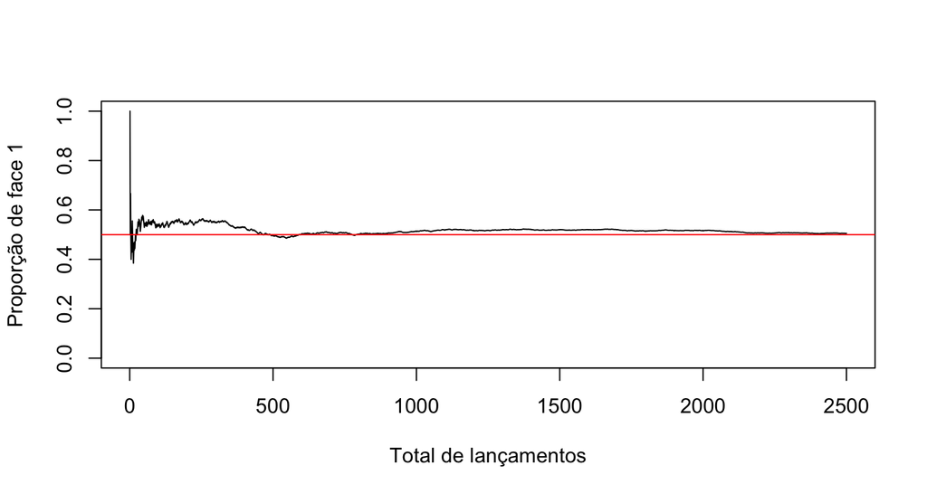

```r
plot(y=resultados$Col5,x=resultados$Col3,type="l",xlab="Total de lançamentos",
     ylab="Proporção de face 1",ylim=c(0,1))
abline(h=0.50,col="red")
```

> A cada simulação (50 lançamentos e anotando o total de 1) obtemos um resultado diferente.

> Se repetirmos as simulação 1000 vezes, temos uma idéia da distribuição de frequências da proporção de 1 em 50 lançamentos.

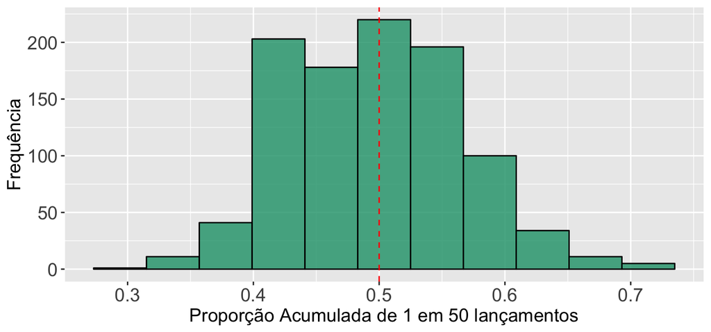

Média: 0.5. Mediana: 0.5. Desvio-padrão: 0.069.

> A cada simulação (100 lançamentos e anotando o total de 1) obtemos um resultado diferente.

> Se repetirmos as simulação 1000 vezes, temos uma idéia da distribuição de frequências da proporção de 1 em 100 lançamentos.

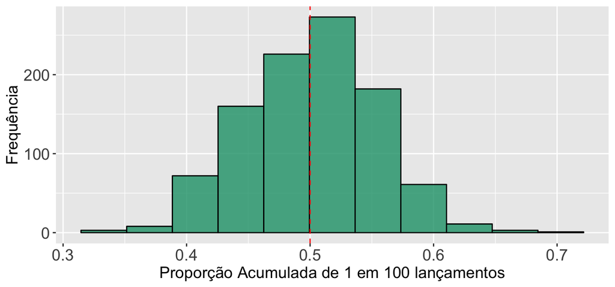

Média: 0.501. Mediana: 0.5. Desvio-padrão: 0.052.

> A cada simulação (500 lançamentos e anotando o total de 1) obtemos um resultado diferente.

> Se repetirmos as simulação 1000 vezes, temos uma idéia da distribuição de frequências da proporção de 1 em 500 lançamentos.

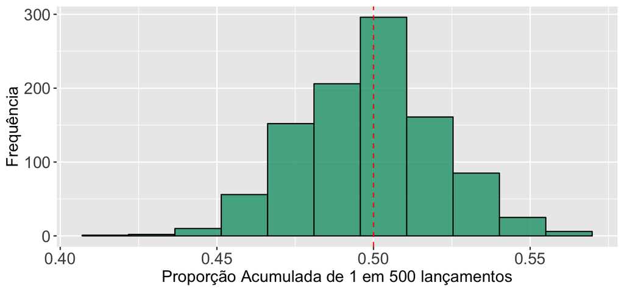

Média: 0.499. Mediana: 0.5. Desvio-padrão: 0.022.

## Mais sobre o R e RStudio

Online (sem instalar): [R-fiddle](http://www.r-fiddle.org/#/)

Informações e tutoriais:

https://me111-unicamp.github.io/aulas/

Livro de estatística básica usando R: http://moderndive.com/index.html

Slides produzidos por:

- Samara Kiihl